# IODS course-final

# Chapter3: Logistic regression

### Data Wrangling exercise

I started the exercise by creating a R script “create_alc.R” and saving it to the “data” folder of my local project repository. Then I read the “student-mat” and “student-por” data sets into R and merged them for the analysis stage. Further description of the data wrangling can be found in the “create_alc.R” script.

### Data analysis exercise

Below you can see the resulting alc data which has 382 observations (rows) and 35 variables (columns).

```r
setwd("C:/Users//Julius//yliopisto//kansis//datascience//IODS-project")
alc <- read.csv("data/student_alc.txt", header = T)
dim(alc)
```

```
## [1] 382  35
```

```r
colnames(alc)
```

```
##  [1] "school"     "sex"        "age"        "address"    "famsize"
##  [6] "Pstatus"    "Medu"       "Fedu"       "Mjob"       "Fjob"
## [11] "reason"     "nursery"    "internet"   "guardian"   "traveltime"
## [16] "studytime"  "failures"   "schoolsup"  "famsup"     "paid"
## [21] "activities" "higher"     "romantic"   "famrel"     "freetime"
## [26] "goout"      "Dalc"       "Walc"       "health"     "absences"
## [31] "G1"         "G2"         "G3"         "alc_use"    "high_use"
```

The dataset describes students’ alcohol consumption, absence from school and exam grades. It also contains information regarding students’ school, sex, age and other backgroud informaation. The alc_use variable describes alcohol use averaged over week and weekend and the high_use is a logical variable of high alcohol use. The data was uploaded from the UCI Machine Learning repository https://archive.ics.uci.edu/ml/datasets/STUDENT+ALCOHOL+CONSUMPTION.

Before running any analyses I selected the “high_use” as my outcome variable and “sex”, “absences,”goout" (going out with friends), and “G3” (grade from the final exam) as predictors. My hypotheses were as follows:

H1: there are more high alcohol consumption in males than females H2: higher absence rates predict higher likelihood of high use H3: Lower grades in the final exam are related to higher probability of high use H4: Higher levels of goout are related to higher probability of high use

Next, I created a subset of the aforementioned variables and saved it into alc_small

```r
alc_small <- alc[, c(2, 26, 30,33,35)]
```

When graphically exploring the distributions of the chosen variables it was found that only the goout was normally distributed. There were almost equal amount of males and females and there were about 100 high users and 300 with low alcohol consumption.

```r
library(tidyr); library(dplyr); library(ggplot2)
gather(alc_small) %>% glimpse
```

```
## Observations: 1,910
## Variables: 2
## $ key   <chr> "sex", "sex", "sex", "sex", "sex", "sex", "sex", "sex", ...
## $ value <chr> "F", "F", "F", "F", "F", "M", "M", "F", "M", "M", "F", "...
```

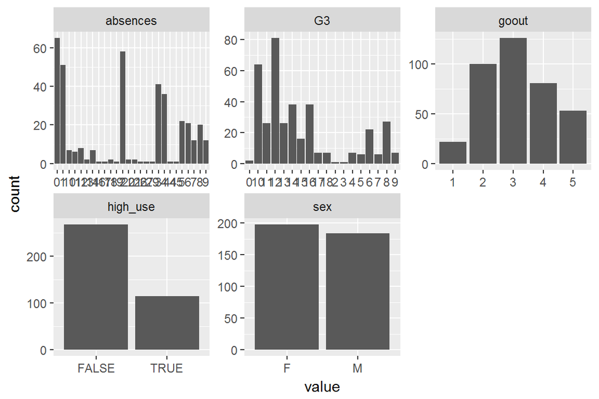

```r
gather(alc_small) %>% ggplot(aes(value)) + facet_wrap("key", scales = "free") + geom_bar()
```

To better understand the relationship of the selected predictors to alcohol use, I printed out a crosstable. That revealed that there were more high users in males and that the grades of high user males were lower than low user males. Additionally, the absences and goout ratings were also higer in high use students.

To sum up, these preliminary findings give support to my hypotheses. The only exception are the exam grades. There the relationship between low grades and alcohol use is only present in males.

```r
alc_small %>% group_by(sex, high_use) %>% summarise(count = n(), mean_grade = mean(G3), Absences = mean(absences), Going_out = mean(goout))
```

```
## Source: local data frame [4 x 6]
## Groups: sex [?]
##
##      sex high_use count mean_grade Absences Going_out
##   <fctr>    <lgl> <int>      <dbl>    <dbl>     <dbl>
## 1      F    FALSE   156   11.39744 4.224359  2.955128
## 2      F     TRUE    42   11.71429 6.785714  3.357143
## 3      M    FALSE   112   12.20536 2.982143  2.714286
## 4      M     TRUE    72   10.27778 6.125000  3.930556
```

To see whether the selected predictors were able to statistically significantly predict high_use, I fitted a logistic regression model adding sex, absences, goout and G3 as predictors and high_use as binary outcome.

```r
m <- glm(high_use ~ sex + absences + goout + G3, data = alc, family = "binomial")
summary(m)
```

```
##
## Call:
## glm(formula = high_use ~ sex + absences + goout + G3, family = "binomial",
##     data = alc)
##
## Deviance Residuals:
##     Min       1Q   Median       3Q      Max
## -1.9286  -0.8055  -0.5308   0.8264   2.4649
##
## Coefficients:
##             Estimate Std. Error z value Pr(>|z|)
## (Intercept) -3.57370    0.68720  -5.200 1.99e-07 ***
## sexM         0.95202    0.25496   3.734 0.000188 ***
## absences     0.08215    0.02237   3.672 0.000241 ***
## goout        0.70844    0.12065   5.872 4.31e-09 ***
## G3          -0.04453    0.03883  -1.147 0.251571
## ---
## Signif. codes:  0 '***' 0.001 '**' 0.01 '*' 0.05 '.' 0.1 ' ' 1
##
## (Dispersion parameter for binomial family taken to be 1)
##
##     Null deviance: 465.68  on 381  degrees of freedom
## Residual deviance: 386.44  on 377  degrees of freedom
## AIC: 396.44
##
## Number of Fisher Scoring iterations: 4
```

Printing out the model summary revealed statistically significant effects of sex, absences, and goout on the high_use. The effect of G3 (grades) was not significant. Then, estimated coefficients were used to calculate odd ratios and their CIs.

```r
OR <- coef(m) %>% exp
CI <- confint(m) %>% exp
cbind(OR, CI)
```

```
##                     OR       2.5 %    97.5 %
## (Intercept) 0.02805195 0.006927766 0.1031581
## sexM        2.59094742 1.581095123 4.3051892
## absences    1.08561394 1.040315244 1.1370409
## goout       2.03082765 1.612303135 2.5901641
## G3          0.95645140 0.886134749 1.0323272
```

Investigating the odd ratios revealed that the risk of high use was 2.59 times more likely in males than females and 2.03 times more likely in persons that used to go out with their friends more often. The absences were also related to higher use but here the effect was more modest (OR = 1.08). Only the G3 odd ratio (takin into account the confidence intervals) was crossing 1 which means that the odds of high use was unaffected by the G3 (the same odds on every level of G3).

Because the G3 did not predict high_use I greated a new logistic regression model (m2) by removing G3 from the formula. The model summary shows that removing the G3 did not change the coefficients of other predictors. Only the intercept was changed from -3.57 to -4.16.

```r
m2 <- glm(high_use ~ sex + absences + goout, data = alc, family = "binomial")
summary (m2)
```

```
##
## Call:
## glm(formula = high_use ~ sex + absences + goout, family = "binomial",
##     data = alc)
##
## Deviance Residuals:
##     Min       1Q   Median       3Q      Max
## -1.7871  -0.8153  -0.5446   0.8357   2.4740
##
## Coefficients:
##             Estimate Std. Error z value Pr(>|z|)
## (Intercept) -4.16317    0.47506  -8.764  < 2e-16 ***
## sexM         0.95872    0.25459   3.766 0.000166 ***
## absences     0.08418    0.02237   3.764 0.000167 ***
## goout        0.72981    0.11970   6.097 1.08e-09 ***
## ---
## Signif. codes:  0 '***' 0.001 '**' 0.01 '*' 0.05 '.' 0.1 ' ' 1
##
## (Dispersion parameter for binomial family taken to be 1)
##
##     Null deviance: 465.68  on 381  degrees of freedom
## Residual deviance: 387.75  on 378  degrees of freedom
## AIC: 395.75
##
## Number of Fisher Scoring iterations: 4
```

The results of m2 were pretty similar to those of m. A chi-square test was calculated to see whether the model fit was better in the more complex “m” than in the “m2”. Thre was no difference in the goodness of fit.

```r
anova(m, m2, test ="Chisq")
```

```
## Analysis of Deviance Table
##
## Model 1: high_use ~ sex + absences + goout + G3
## Model 2: high_use ~ sex + absences + goout
##   Resid. Df Resid. Dev Df Deviance Pr(>Chi)
## 1       377     386.44
## 2       378     387.75 -1  -1.3119    0.252
```

The odd ratios show again that sex and goout had the highest prediction power.

```r
OR <- coef(m2) %>% exp
CI <- confint(m2) %>% exp
cbind(OR, CI)
```

```
##                     OR       2.5 %     97.5 %
## (Intercept) 0.01555815 0.005885392 0.03804621
## sexM        2.60835292 1.593132148 4.33151387
## absences    1.08782902 1.042458467 1.13933894
## goout       2.07468346 1.650182481 2.64111050
```

The m2 was then used to create a prediction variable. The prediction was used to see how much the actual data differs from the predicted values.

```r
# predicting the probability of high_use
probabilities <- predict(m2, type = "response")

# add the predicted probabilities to 'alc'
alc <- mutate(alc, probability = probabilities)

# adding a logical variable of succesfull predictions
alc <- mutate(alc, prediction = probability > 0.5 )
```

Drawing a crosstab of probabilities of the model to give wrong answer revealed that in 66% out of 83% of cases the model correctly predicted low use and in 12% out of 16.7% cases the model was corrent in predicting high use.

```r
# drawing a crosstab of probabilities
table(high_use = alc$high_use, prediction = alc$prediction) %>% prop.table() %>% addmargins()
```

```
##         prediction
## high_use      FALSE       TRUE        Sum
##    FALSE 0.66230366 0.03926702 0.70157068
##    TRUE  0.17015707 0.12827225 0.29842932
##    Sum   0.83246073 0.16753927 1.00000000
```

Finally, I calculated the penalty/loss rate which indicates how many times the model classified observations incorrectly. In order to do so, I defined a loss function and feed in the probability and correct (high_use) values.The average number of incorrect predictions was 20.9.

```r
loss_func <- function(class, prob) {
  n_wrong <- abs(class - prob) > 0.5
  mean(n_wrong)
}

loss_func(class = alc$high_use, prob = alc$probability)
```

```
## [1] 0.2094241
```

```r
library(boot)
# K-fold cross-validation
cv <- cv.glm(data = alc, cost = loss_func, glmfit = m, K = 10)

# average number of wrong answers
cv$delta[1]
```

[output not shown]

# Chapter4: Clustering and Classification techniques

```r
#this week's needed packages
library(MASS)
library(dplyr)
library(GGally)
library(ggplot2)
library(tidyr)
library(corrplot)
library(plotly)
```

For this week we will be using ‘Boston’ dataset from the ‘MASS’ R package which includes 14 variables with 506 observations. Variables include:

1. per capita crime rate by town.
2. proportion of residential land zoned for lots over 25,000 sq.ft.
3. proportion of non-retail business acres per town.
4. Charles River dummy variable (= 1 if tract bounds river; 0 otherwise).
5. nitrogen oxides concentration (parts per 10 million).
6. average number of rooms per dwelling.
7. proportion of owner-occupied units built prior to 1940.
8. weighted mean of distances to five Boston employment centres.
9. index of accessibility to radial highways.
10. full-value property-tax rate per $10,000.
11. pupil-teacher ratio by town.
12. 1000(Bk - 0.63)^2 where Bk is the proportion of blacks by town.
13. lower status of the population (percent).
14. median value of owner-occupied homes in $1000s.

```r
data("Boston")
glimpse(Boston)
```

```
## Observations: 506
## Variables: 14
## $ crim    <dbl> 0.00632, 0.02731, 0.02729, 0.03237, 0.06905, 0.02985, ...
## $ zn      <dbl> 18.0, 0.0, 0.0, 0.0, 0.0, 0.0, 12.5, 12.5, 12.5, 12.5,...
## $ indus   <dbl> 2.31, 7.07, 7.07, 2.18, 2.18, 2.18, 7.87, 7.87, 7.87, ...
## $ chas    <int> 0, 0, 0, 0, 0, 0, 0, 0, 0, 0, 0, 0, 0, 0, 0, 0, 0, 0, ...
## $ nox     <dbl> 0.538, 0.469, 0.469, 0.458, 0.458, 0.458, 0.524, 0.524...
## $ rm      <dbl> 6.575, 6.421, 7.185, 6.998, 7.147, 6.430, 6.012, 6.172...
## $ age     <dbl> 65.2, 78.9, 61.1, 45.8, 54.2, 58.7, 66.6, 96.1, 100.0,...
## $ dis     <dbl> 4.0900, 4.9671, 4.9671, 6.0622, 6.0622, 6.0622, 5.5605...
## $ rad     <int> 1, 2, 2, 3, 3, 3, 5, 5, 5, 5, 5, 5, 5, 4, 4, 4, 4, 4, ...
## $ tax     <dbl> 296, 242, 242, 222, 222, 222, 311, 311, 311, 311, 311,...
## $ ptratio <dbl> 15.3, 17.8, 17.8, 18.7, 18.7, 18.7, 15.2, 15.2, 15.2, ...
## $ black   <dbl> 396.90, 396.90, 392.83, 394.63, 396.90, 394.12, 395.60...
## $ lstat   <dbl> 4.98, 9.14, 4.03, 2.94, 5.33, 5.21, 12.43, 19.15, 29.9...
## $ medv    <dbl> 24.0, 21.6, 34.7, 33.4, 36.2, 28.7, 22.9, 27.1, 16.5, ...
```

Next we look at the distributions and descriptive statistics for the Boston dataset.

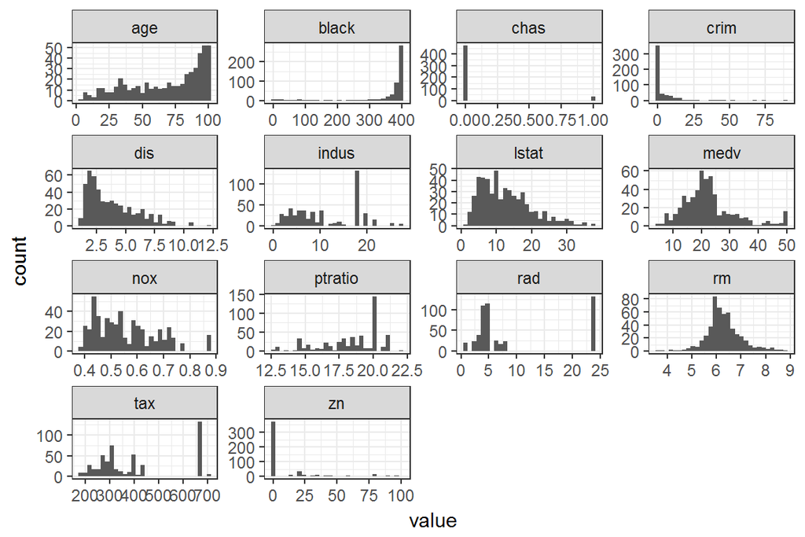

```r
gather(Boston) %>%
  ggplot(aes(value)) + facet_wrap("key", scales= "free") + geom_histogram() + theme_bw()
```

```r
summary(Boston)
```

```
##       crim                zn             indus            chas
##  Min.   : 0.00632   Min.   :  0.00   Min.   : 0.46   Min.   :0.00000
##  1st Qu.: 0.08204   1st Qu.:  0.00   1st Qu.: 5.19   1st Qu.:0.00000
##  Median : 0.25651   Median :  0.00   Median : 9.69   Median :0.00000
##  Mean   : 3.61352   Mean   : 11.36   Mean   :11.14   Mean   :0.06917
##  3rd Qu.: 3.67708   3rd Qu.: 12.50   3rd Qu.:18.10   3rd Qu.:0.00000
##  Max.   :88.97620   Max.   :100.00   Max.   :27.74   Max.   :1.00000
##       nox               rm             age              dis
##  Min.   :0.3850   Min.   :3.561   Min.   :  2.90   Min.   : 1.130
##  1st Qu.:0.4490   1st Qu.:5.886   1st Qu.: 45.02   1st Qu.: 2.100
##  Median :0.5380   Median :6.208   Median : 77.50   Median : 3.207
##  Mean   :0.5547   Mean   :6.285   Mean   : 68.57   Mean   : 3.795
##  3rd Qu.:0.6240   3rd Qu.:6.623   3rd Qu.: 94.08   3rd Qu.: 5.188
##  Max.   :0.8710   Max.   :8.780   Max.   :100.00   Max.   :12.127
##       rad              tax           ptratio          black
##  Min.   : 1.000   Min.   :187.0   Min.   :12.60   Min.   :  0.32
##  1st Qu.: 4.000   1st Qu.:279.0   1st Qu.:17.40   1st Qu.:375.38
##  Median : 5.000   Median :330.0   Median :19.05   Median :391.44
##  Mean   : 9.549   Mean   :408.2   Mean   :18.46   Mean   :356.67
##  3rd Qu.:24.000   3rd Qu.:666.0   3rd Qu.:20.20   3rd Qu.:396.23
##  Max.   :24.000   Max.   :711.0   Max.   :22.00   Max.   :396.90
##      lstat            medv
##  Min.   : 1.73   Min.   : 5.00
##  1st Qu.: 6.95   1st Qu.:17.02
##  Median :11.36   Median :21.20
##  Mean   :12.65   Mean   :22.53
##  3rd Qu.:16.95   3rd Qu.:25.00
##  Max.   :37.97   Max.   :50.00
```

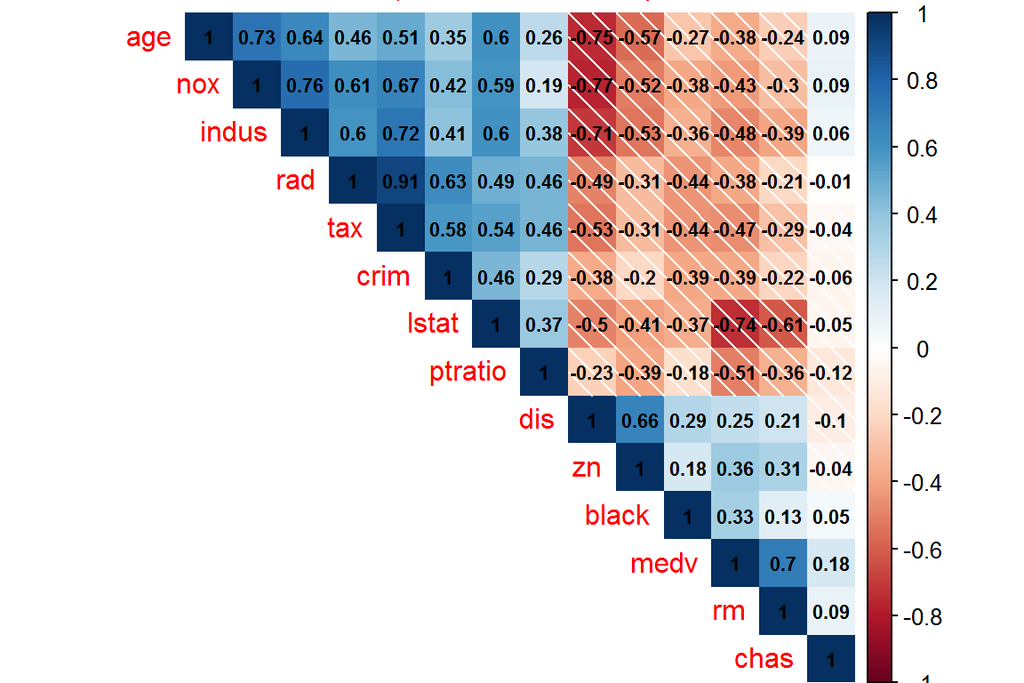

```r
Boston.corr <- cor(Boston)
corrplot(Boston.corr, type="upper", order = "AOE" ,method = "shade", addCoef.col = T, number.cex = 0.7)
```

Next we need to scale the Boston dataset for the use of LDA and convert it back to dataframe

```r
Boston.scaled <- scale(Boston)
summary(Boston.scaled)
```

```
##       crim                 zn               indus
##  Min.   :-0.419367   Min.   :-0.48724   Min.   :-1.5563
##  1st Qu.:-0.410563   1st Qu.:-0.48724   1st Qu.:-0.8668
##  Median :-0.390280   Median :-0.48724   Median :-0.2109
##  Mean   : 0.000000   Mean   : 0.00000   Mean   : 0.0000
##  3rd Qu.: 0.007389   3rd Qu.: 0.04872   3rd Qu.: 1.0150
##  Max.   : 9.924110   Max.   : 3.80047   Max.   : 2.4202
##       chas              nox                rm               age
##  Min.   :-0.2723   Min.   :-1.4644   Min.   :-3.8764   Min.   :-2.3331
##  1st Qu.:-0.2723   1st Qu.:-0.9121   1st Qu.:-0.5681   1st Qu.:-0.8366
##  Median :-0.2723   Median :-0.1441   Median :-0.1084   Median : 0.3171
##  Mean   : 0.0000   Mean   : 0.0000   Mean   : 0.0000   Mean   : 0.0000
##  3rd Qu.:-0.2723   3rd Qu.: 0.5981   3rd Qu.: 0.4823   3rd Qu.: 0.9059
##  Max.   : 3.6648   Max.   : 2.7296   Max.   : 3.5515   Max.   : 1.1164
##       dis               rad               tax             ptratio
##  Min.   :-1.2658   Min.   :-0.9819   Min.   :-1.3127   Min.   :-2.7047
##  1st Qu.:-0.8049   1st Qu.:-0.6373   1st Qu.:-0.7668   1st Qu.:-0.4876
##  Median :-0.2790   Median :-0.5225   Median :-0.4642   Median : 0.2746
##  Mean   : 0.0000   Mean   : 0.0000   Mean   : 0.0000   Mean   : 0.0000
##  3rd Qu.: 0.6617   3rd Qu.: 1.6596   3rd Qu.: 1.5294   3rd Qu.: 0.8058
##  Max.   : 3.9566   Max.   : 1.6596   Max.   : 1.7964   Max.   : 1.6372
##      black             lstat              medv
##  Min.   :-3.9033   Min.   :-1.5296   Min.   :-1.9063
##  1st Qu.: 0.2049   1st Qu.:-0.7986   1st Qu.:-0.5989
##  Median : 0.3808   Median :-0.1811   Median :-0.1449
##  Mean   : 0.0000   Mean   : 0.0000   Mean   : 0.0000
##  3rd Qu.: 0.4332   3rd Qu.: 0.6024   3rd Qu.: 0.2683
##  Max.   : 0.4406   Max.   : 3.5453   Max.   : 2.9865
```

```r
Boston.scaled <- as.data.frame(Boston.scaled)
```

```r
#crim variable to quantiles
crim.scaled <- Boston.scaled$crim
quantiles <- quantile(crim.scaled)

#quantile names
quantile.names <- c("low", "med_low", "med_high", "high")

# cut crime from original to new quantiles
crime.quantile <- cut(crim.scaled, breaks = quantiles, include.lowest = T, label = quantile.names)

Boston.scaled <- select(Boston.scaled, -crim)
Boston.scaled <- cbind(Boston.scaled, crime.quantile)
```

Next we break the data into test and training dataset

```r
n <- nrow(Boston.scaled)

#choose 80%
ind <- sample(n,  size = n * 0.8)

#training set
train <- Boston.scaled[ind,]

#test set
test <- Boston.scaled[-ind,]

# save classes from test data to a  independent variable
correct_classes <- test$crime.quantile

# remove crime from test
test <- dplyr::select(test, -crime.quantile)
```

Next we fit LDA to our training data using crime.quantiles as target variable and rest of the variables as predictors.

```r
lda.fit <- lda(crime.quantile ~ ., data=train)
lda.fit
```

```
## Call:
## lda(crime.quantile ~ ., data = train)
##
## Prior probabilities of groups:
##       low   med_low  med_high      high
## 0.2524752 0.2450495 0.2450495 0.2574257
##
## Group means:
##                   zn      indus        chas        nox          rm
## low       0.90815839 -0.9089617 -0.11793298 -0.8734952  0.40962107
## med_low  -0.03291578 -0.3987648 -0.03371693 -0.5937043 -0.03918689
## med_high -0.39109146  0.1780379  0.20489520  0.4229634  0.09625191
## high     -0.48724019  1.0170690 -0.04518867  1.0555489 -0.40914306
##                 age        dis        rad        tax    ptratio      black
## low      -0.9345413  0.8894324 -0.6879988 -0.7161505 -0.4957079  0.3738810
## med_low  -0.3595657  0.4185319 -0.5375653 -0.5696361 -0.1003026  0.3300838
## med_high  0.4083574 -0.3917483 -0.3913967 -0.2855516 -0.2771331  0.0656161
## high      0.8226902 -0.8526565  1.6386213  1.5144083  0.7813507 -0.7506245
##                lstat        medv
## low      -0.75611109  0.49531123
## med_low  -0.20898240  0.06485592
## med_high  0.02927548  0.18006565
## high      0.82689633 -0.67403309
##
## Coefficients of linear discriminants:
##                 LD1         LD2         LD3
## zn       0.15033391  0.59405501 -0.94714934
## indus    0.01555305 -0.20374978  0.38845793
## chas    -0.06197188 -0.06119055  0.05764916
## nox      0.31137285 -0.76592141 -1.26527195
## rm      -0.09399012 -0.08288391 -0.12810835
## age      0.33373005 -0.33810906  0.15320174
## dis     -0.13565248 -0.20636266  0.30299497
## rad      2.76297230  1.37910995  0.47064395
## tax      0.24203522 -0.40226169 -0.22059126
## ptratio  0.12810950 -0.13366815 -0.22657952
## black   -0.12997680  0.03563990  0.13626281
## lstat    0.20640354 -0.23174332  0.25461032
## medv     0.18588453 -0.47013544 -0.25992364
##
## Proportion of trace:
##    LD1    LD2    LD3
## 0.9485 0.0415 0.0100
```

Next we draw the LDA (bi)plot to visualize the previous results from fitting the LDA.

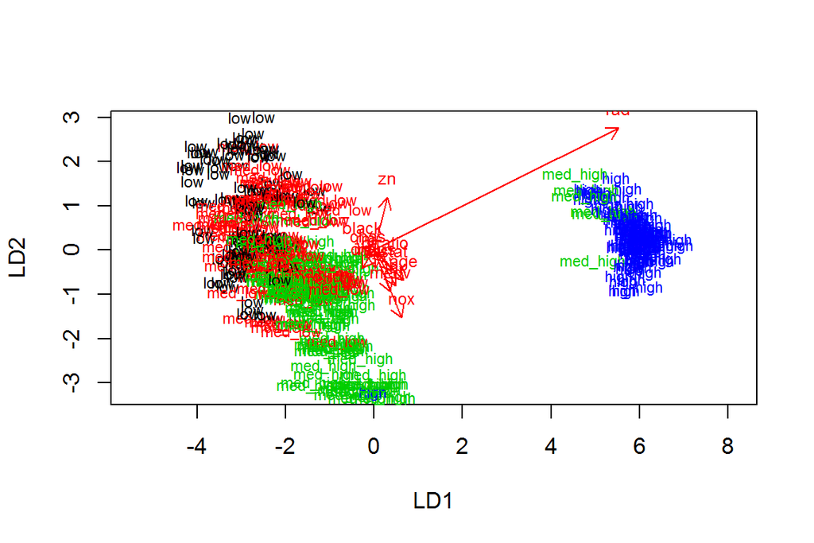

```r
lda.arrows <- function(x, myscale = 1, arrow_heads = 0.1, color = "red", tex = 0.75, choices = c(1,2)){
  heads <- coef(x)
  arrows(x0 = 0, y0 = 0,
         x1 = myscale * heads[,choices[1]],
         y1 = myscale * heads[,choices[2]], col=color, length = arrow_heads)
  text(myscale * heads[,choices], labels = row.names(heads),
       cex = tex, col=color, pos=3)
}

# target needs to be numeric
classes <- as.numeric(train$crime)

# plot
plot(lda.fit, dimen = 2, col = classes, pch = classes)
lda.arrows(lda.fit, myscale = 2)
```

From the picture can be seen that LD1 is good at separating high crime and then LD2 (up down) can further separate other 3 lower crime rates.

But next we see how well we can predict the classes

```r
lda.pred <- predict(lda.fit, newdata = test)

table(correct = correct_classes, predicted = lda.pred$class)
```

```
##           predicted
## correct    low med_low med_high high
##   low       14      10        1    0
##   med_low    3      15        9    0
##   med_high   2       9       16    0
##   high       0       0        0   23
```

Next we move on to utilising k-means with Boston dataset

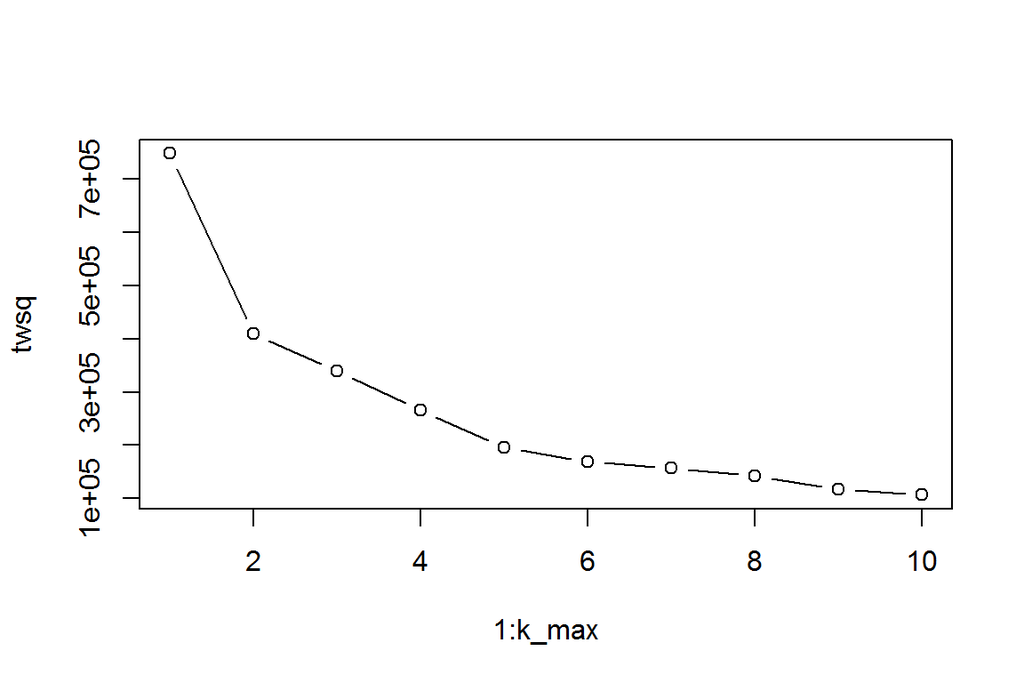

```r
data('Boston')

#clustering works only on scaled data
Boston.scaled2 <- scale(Boston)
set.seed(123)

#we need distance matrix for clustering
Boston.distance <- dist(Boston.scaled2)

#maximum number of hypothetical clusters

k_max <- 10

# total within sum of squares
twsq <- sapply(1:k_max, function(k){kmeans(Boston.distance, k)$tot.withinss})

plot(1:k_max, twsq, type = "b")
```

Inteptreting the graph looks like optimum number of clusters is 2 (has the sharpest drop in the within cluster variation). So next we run the kmeans for 2 clusters.

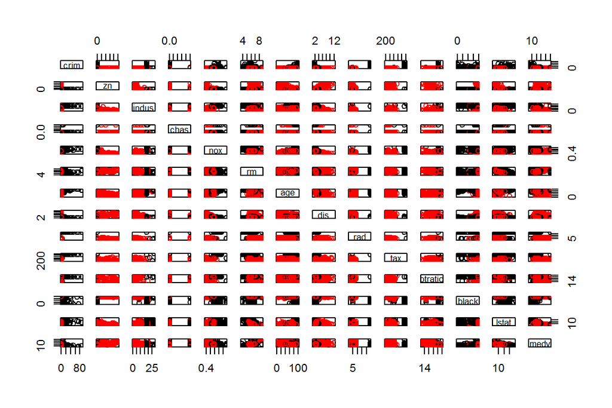

```r
boston.kmeans2 <- kmeans(Boston.distance, centers = 2)

#plot the dataset
pairs(Boston, col = boston.kmeans2$cluster)
```

From the graph we can see that rad and tax were most important separators for the clusters

### BONUS1:

I perform LDA using kmeans with 3 cluster centers.

```r
#kmeans with 3 clusters on Boston dataset
boston.kmeans3 <- kmeans(Boston.distance, centers = 3)

#LDA on the previous kmeans results
lda.fit <- lda(boston.kmeans3$cluster ~ ., data = Boston)
lda.fit
```

```
## Call:
## lda(boston.kmeans3$cluster ~ ., data = Boston)
##
## Prior probabilities of groups:
##         1         2         3
## 0.1699605 0.2964427 0.5335968
##
## Group means:
##        crim          zn     indus       chas       nox       rm      age
## 1 14.410307  1.04651163 18.412791 0.18604651 0.6955465 5.889453 92.21977
## 2  3.594889  0.08333333 16.201800 0.02666667 0.6192800 6.036413 88.09867
## 3  0.184901 20.91666667  6.005333 0.05555556 0.4739507 6.548407 50.19704
##        dis       rad      tax  ptratio    black     lstat     medv
## 1 1.810314 19.941860 616.1279 19.23721 231.9315 20.426628 16.44186
## 2 2.561713 12.773333 496.2600 19.56667 369.0913 16.157333 18.00800
## 3 5.112399  4.448148 293.1185 17.58926 389.5083  8.230222 26.98667
##
## Coefficients of linear discriminants:
##                  LD1           LD2
## crim    -0.030828366  0.0869664519
## zn      -0.015314358 -0.0059126472
## indus   -0.069679715 -0.0883096847
## chas    -1.339918668  1.6001162814
## nox     -5.141704866  3.0477474546
## rm       0.391059024 -0.3225584287
## age     -0.009923483 -0.0211950792
## dis      0.090002927  0.1210279332
## rad      0.046659074 -0.0163781763
## tax     -0.005000880 -0.0001812208
## ptratio -0.139896301 -0.0984855812
## black    0.006186019 -0.0092407719
## lstat   -0.072113484  0.0424045403
## medv    -0.037617137  0.0666347548
##
## Proportion of trace:
##    LD1    LD2
## 0.8828 0.1172
```

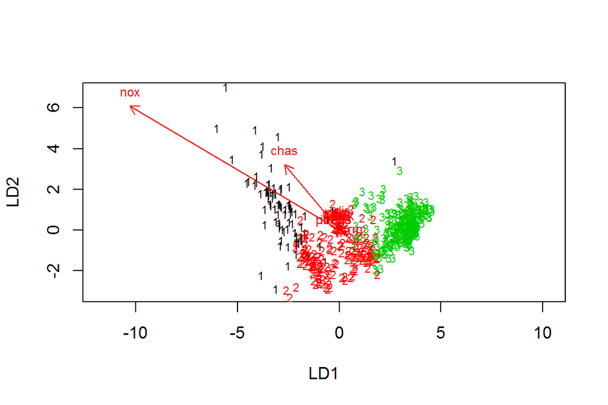

```r
#plot the previous lda
plot(lda.fit, dimen = 2, col = boston.kmeans3$cluster, pch = boston.kmeans3$cluster)
lda.arrows(lda.fit, myscale = 2)
```

From plotting the (bi)plot it can be seen that LD1 separates variables very well. Nox and Chas variables were the most influential ones in providing information for separation.

# Chapter5: Dimensionality reduction techniques

```r
#needed libraries
library(GGally)
library(FactoMineR)
library(dplyr)
library(ggplot2)
library(tidyr)
```

First we start by downloading the ‘human’ dataset from the data wrangling part (described in the data wrangling directory) and do basic descriptive statistics.

```r
human <- read.csv("data/human.csv", row.names = 1)
dim(human)
```

```
## [1] 155   8
```

```r
str(human)
```

```
## 'data.frame':    155 obs. of  8 variables:
##  $ eduF2M          : num  1.007 0.997 0.983 0.989 0.969 ...
##  $ labourF2m       : num  0.891 0.819 0.825 0.884 0.829 ...
##  $ eduexpect       : num  17.5 20.2 15.8 18.7 17.9 16.5 18.6 16.5 15.9 19.2 ...
##  $ lifexpect       : num  81.6 82.4 83 80.2 81.6 80.9 80.9 79.1 82 81.8 ...
##  $ gni             : int  64992 42261 56431 44025 45435 43919 39568 52947 42155 32689 ...
##  $ mortality       : int  4 6 6 5 6 7 9 28 11 8 ...
##  $ adole_birth     : num  7.8 12.1 1.9 5.1 6.2 3.8 8.2 31 14.5 25.3 ...
##  $ parlia_represent: num  39.6 30.5 28.5 38 36.9 36.9 19.9 19.4 28.2 31.4 ...
```

```r
colnames(human)
```

```
## [1] "eduF2M"           "labourF2m"        "eduexpect"
## [4] "lifexpect"        "gni"              "mortality"
## [7] "adole_birth"      "parlia_represent"
```

Our dataset has 155 countries and 8 variables. The data has no missing values because countries with them were cleaned in the earlier data wrangling part. Our variables describe characteristics in education, health, economy, political activity and gender equality

Next we do some graphical exploratory analysis

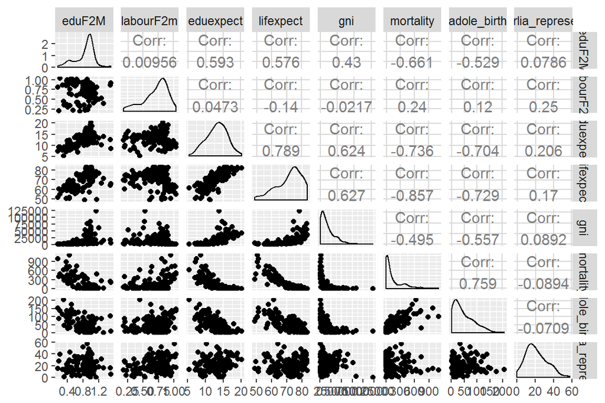

```r
ggpairs(human)
```

Next we do principal component analysis without scaling our variables

```r
pca_human <- prcomp(human)
summary(pca_human)
```

```
## Importance of components:
##                              PC1      PC2   PC3   PC4   PC5   PC6    PC7
## Standard deviation     1.854e+04 185.5219 25.19 11.45 3.766 1.566 0.1912
## Proportion of Variance 9.999e-01   0.0001  0.00  0.00 0.000 0.000 0.0000
## Cumulative Proportion  9.999e-01   1.0000  1.00  1.00 1.000 1.000 1.0000
##                           PC8
## Standard deviation     0.1591
## Proportion of Variance 0.0000
## Cumulative Proportion  1.0000
```

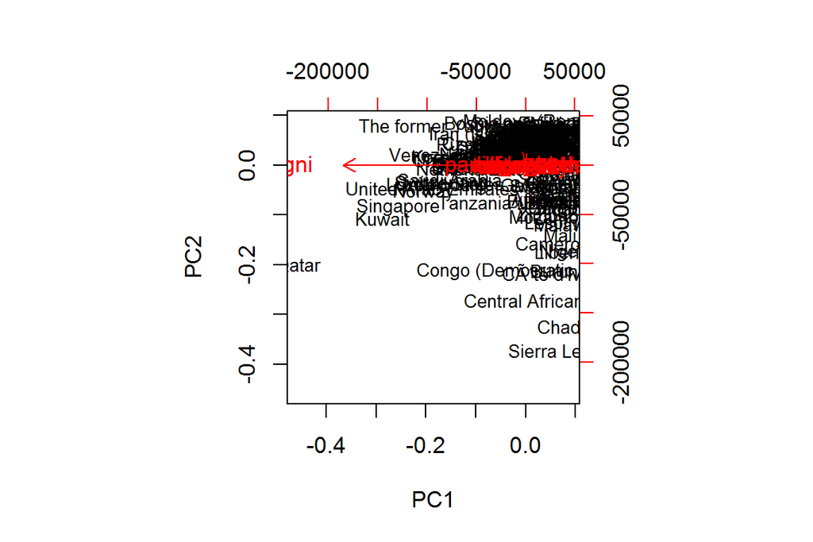

```r
biplot(pca_human, choices = 1:2, cex = c(0.8,1))
```

Using non-standardized data confirms the notion that it’s not advisable to use non-standardized data with pca. Huge differences in variable scales makes all the proportions of variance explained by each principal component minimal (after the first one). Biplot visualises the same thing by showing that GNI is the main (only) driver in variance.

Next we scale the data and repeat the procedure

```r
human_scaled <- scale(human)
pca_human_scaled <- prcomp(human_scaled)
summary(pca_human_scaled)
```

```
## Importance of components:
##                           PC1    PC2     PC3     PC4     PC5     PC6
## Standard deviation     2.0708 1.1397 0.87505 0.77886 0.66196 0.53631
## Proportion of Variance 0.5361 0.1624 0.09571 0.07583 0.05477 0.03595
## Cumulative Proportion  0.5361 0.6984 0.79413 0.86996 0.92473 0.96069
##                            PC7     PC8
## Standard deviation     0.45900 0.32224
## Proportion of Variance 0.02634 0.01298
## Cumulative Proportion  0.98702 1.00000
```

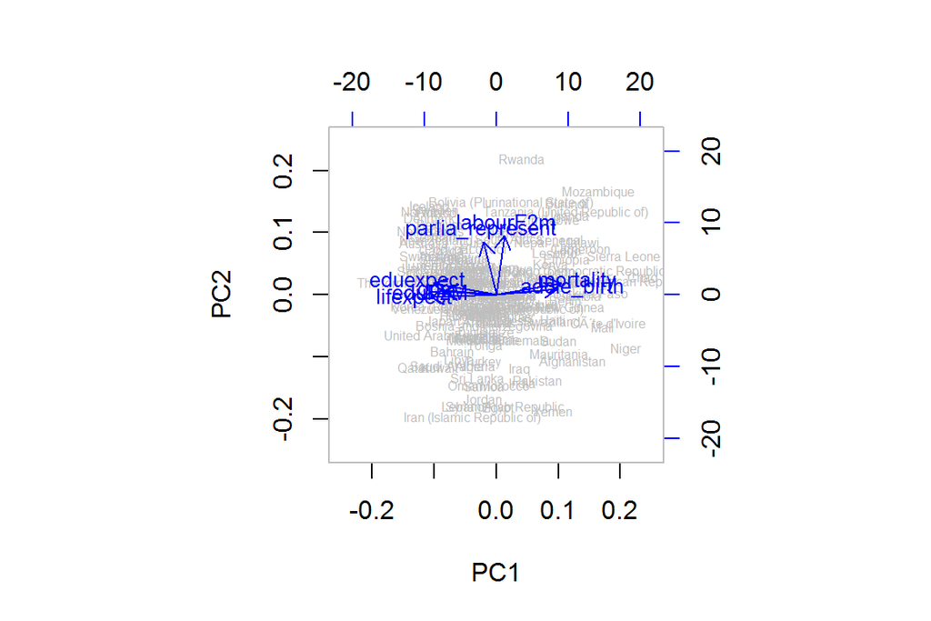

```r
biplot(pca_human_scaled, choices = 1:2, cex = c(0.5,0.8), col = c("grey", "blue"), xlim  = c(-0.25, 0.25), ylim  = c(-0.25, 0.25))
```

Above results can be intepreted as that first principal component explains 53.6% of the variance, 2nd 16.2% and 3rd 9.6%.

Biplot reveals that first principal component consists mostly of expected education duration, education gender gap, GNI, life expectancy, child mortality and adolescent birth rate.

2nd principal component consists of labour gender equality and women represented in parliament

General explanations for principal components can be seen as: 1st PC could be viewed as human development and 2nd one as governmental and labour gender equality.

### Tea time! Extra dataset for the chapter5 to use with MCA (multiple correspondence analysis)

Exploratory and descriptive data analysis:

```r
data("tea")
dim(tea)
```

```
## [1] 300  36
```

```r
colnames(tea)
```

```
##  [1] "breakfast"        "tea.time"         "evening"
##  [4] "lunch"            "dinner"           "always"
##  [7] "home"             "work"             "tearoom"
## [10] "friends"          "resto"            "pub"
## [13] "Tea"              "How"              "sugar"
## [16] "how"              "where"            "price"
## [19] "age"              "sex"              "SPC"
## [22] "Sport"            "age_Q"            "frequency"
## [25] "escape.exoticism" "spirituality"     "healthy"
## [28] "diuretic"         "friendliness"     "iron.absorption"
## [31] "feminine"         "sophisticated"    "slimming"
## [34] "exciting"         "relaxing"         "effect.on.health"
```

To make it simpler we take subset of data consisting of 6 variables.

1. sex
2. tea.time
3. healthy
4. price
5. iron.absorption
6. spirituality

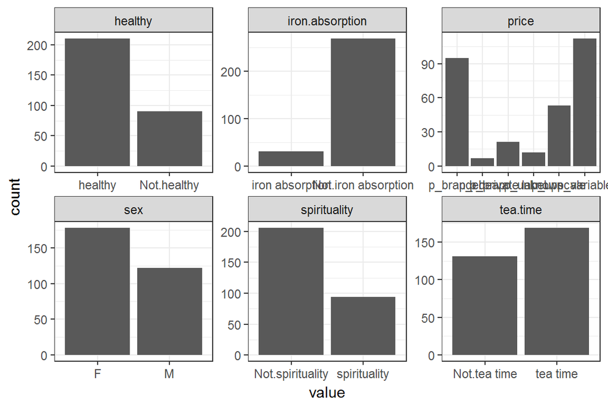

```r
#variables which we keep
keep_variables <- c("sex", "tea.time", "healthy", "price", "iron.absorption", "spirituality")
tea_6 <- select(tea, one_of(keep_variables))

gather(tea_6) %>% ggplot(aes(value)) + facet_wrap("key", scales = "free") + geom_bar() + theme_bw()
```

Our final dataset includes 6 variables for 300 persons. Only price variable is multilevel, other’s were binary. Variable graph is fortunately self explanatory for visualisation in this small dataset.

Next we run multiple correspondence analysis (MCA). With MCA we can analyze categorical variables compared to PCA which works only with continuous variables.

```r
mca <- MCA(tea_6, graph = FALSE)
summary(mca)
```

```
##
## Call:
## MCA(X = tea_6, graph = FALSE)
##
##
## Eigenvalues
##                        Dim.1   Dim.2   Dim.3   Dim.4   Dim.5   Dim.6
## Variance               0.225   0.197   0.185   0.172   0.167   0.166
## % of var.             13.485  11.835  11.116  10.327  10.044   9.972
## Cumulative % of var.  13.485  25.319  36.435  46.762  56.807  66.778
##                        Dim.7   Dim.8   Dim.9  Dim.10
## Variance               0.162   0.149   0.137   0.107
## % of var.              9.693   8.915   8.191   6.422
## Cumulative % of var.  76.471  85.386  93.578 100.000
##
## Individuals (the 10 first)
##                    Dim.1    ctr   cos2    Dim.2    ctr   cos2    Dim.3
## 1               |  1.039  1.600  0.233 |  0.061  0.006  0.001 | -0.047
## 2               | -0.033  0.002  0.001 | -0.242  0.099  0.076 |  0.061
## 3               | -0.507  0.381  0.372 |  0.085  0.012  0.010 |  0.078
## 4               |  0.572  0.485  0.274 | -0.405  0.277  0.137 |  0.690
## 5               |  0.614  0.559  0.249 |  0.212  0.076  0.030 |  0.750
## 6               |  0.674  0.673  0.160 |  0.003  0.000  0.000 | -0.333
## 7               |  0.072  0.008  0.006 |  0.103  0.018  0.013 |  0.117
## 8               | -0.507  0.381  0.372 |  0.085  0.012  0.010 |  0.078
## 9               |  0.403  0.241  0.100 |  0.864  1.263  0.458 | -0.159
## 10              |  0.835  1.035  0.498 | -0.079  0.011  0.004 | -0.237
##                    ctr   cos2
## 1                0.004  0.000 |
## 2                0.007  0.005 |
## 3                0.011  0.009 |
## 4                0.856  0.398 |
## 5                1.011  0.372 |
## 6                0.200  0.039 |
## 7                0.025  0.017 |
## 8                0.011  0.009 |
## 9                0.046  0.016 |
## 10               0.101  0.040 |
##
## Categories (the 10 first)
```

[output cut: 16 more lines]

```
## healthy           0.567 -13.016 |  -0.046   0.135   0.005  -1.225 |
## Not.healthy       0.567  13.016 |   0.108   0.316   0.005   1.225 |
## p_branded         0.225  -8.206 |  -0.779  17.298   0.281  -9.173 |
## p_cheap           0.012   1.860 |  -2.059   8.902   0.101  -5.504 |
## p_private label   0.037   3.328 |  -0.297   0.557   0.007  -1.411 |
## p_unknown         0.030   3.018 |   0.440   0.698   0.008   1.555 |
##
## Categorical variables (eta2)
##                   Dim.1 Dim.2 Dim.3
## sex             | 0.653 0.001 0.002 |
## tea.time        | 0.447 0.187 0.000 |
## healthy         | 0.003 0.567 0.005 |
## price           | 0.158 0.273 0.557 |
## iron.absorption | 0.086 0.106 0.047 |
## spirituality    | 0.001 0.050 0.499 |
```

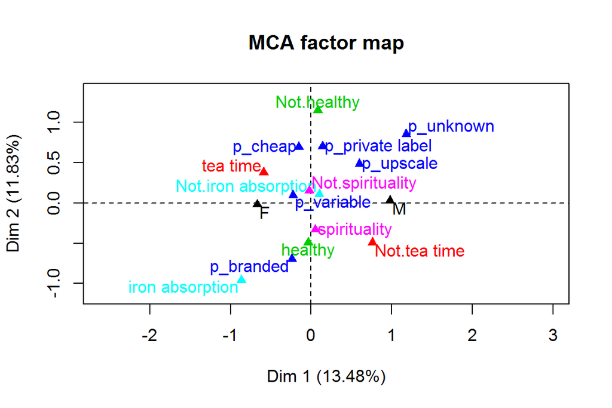

```r
plot(mca, invisible = c("ind"), habillage = c("quali"))
```

Variables don’t load really smoothly on the dimensions. Reason could be that I accidentally tried to choose different kind of variables. Dimension 1 makes the most clear difference for sex (65% eta value) and tea.time (44%). 2nd dimension looks to be mostly about healthiness and price.